# Milestone Report - NLP and Text predictions

Alberto Macías

5/27/2021

# Introduction

This is the milestone report for the second week of the Data Science Specialization’s Capstone, given at Coursera by John Hopkins University. The intention for this report is to perform an exploratory data analysis on three text documents: collections of tweets, news and reports, all the three in English, provided by Swiftkey company and Coursera. In the first part, three text documents are loaded to the environment, clean and pre-processed. The whole processed of cleaning is explained on the twitter corpus, but the other documents will be cleaned and pre-processed in the same way and with the same nomenclature.

In the next part, I make an exploratory data analysis on the resulting data. The features that will be studied are: most frequent words, most frequent $n$-grams, with $n=2,3$, association of the top ten most frequent words with all the corpus and how many words are needed in order to cover $50\%$, $90\%$ and $95\%$ of the whole corpus.

In the final part, I’ll explain the work plan for a predictive text model, the goals of the model and the challenges.

## Libraries for the analysis

The following libraries will be used to clean and pre-process the data and to perform the analysis.

```r
library(dplyr)
library(ggplot2)
library(gridExtra)

library(stringr)
library(tidytext)
library(tm) # Text mining
library(tokenizers) # Tokenize the data
library(wordcloud) # Wordclouds
library(RColorBrewer)
```

## Loading data and preparing corpus

Since the twitter corpus is quite large, I will take a random sample, in order to improve time and memory cost on the analysis.

```r
file.txt <- "./final/en_Us/en_US.twitter.txt"
con <- file(file.txt, "r")
twitter_corpus <- readLines(con)
close(con)
length(twitter_corpus)
```

```
## [1] 2360148
```

```r
set.seed(22)
selection <- sample(1:length(twitter_corpus), 100000)
twitter_corpus <- twitter_corpus[selection]
twitter_corpus <- Corpus(VectorSource(twitter_corpus),
                         readerControl=list(readPlain, language="en_US", load=TRUE))
inspect(twitter_corpus[1:4])
```

```
## <<SimpleCorpus>>
## Metadata:  corpus specific: 1, document level (indexed): 0
## Content:  documents: 4
##
## [1] tomorrow* that is.
## [2] Gronkowski was open but he went to Danny Woodhead instead. TOUCHDOWN Patriots. Patriots lead 10-9.
## [3] Totally agree! I Hope they execute his ass!
## [4] I think Title V was funded for the first 5-6 yrs after NCLB signing. Haven't found a source on funding of Part B (charters)
```

## Data cleaning

The following is my plan to clean and pre-process the data:

- transform text to lowercase
- remove punctuation, numbers and symbols
- stem the corpus
- filter the profanities
- remove stop words
- remove extra white spaces
- create $n$-grams of the text, for $n=1,2,3$
- Create a Document Term Matrix.

First, I transform to lowercase the corpus, remove the punctuation, remove the numbers and stem the corpus.

```r
twitter_corpus <- tm_map(twitter_corpus, content_transformer(tolower))
twitter_corpus <- tm_map(twitter_corpus, removePunctuation)
twitter_corpus <- tm_map(twitter_corpus, stemDocument)
twitter_corpus <- tm_map(twitter_corpus, removeNumbers)
```

The next part is to filter the profanities. In order to do this, I use a profanity dictionary from the lexicon package, that contains 77 stop words and I check the profanity rate on the Twitter corpus with the profanity function of the sentimentR package.

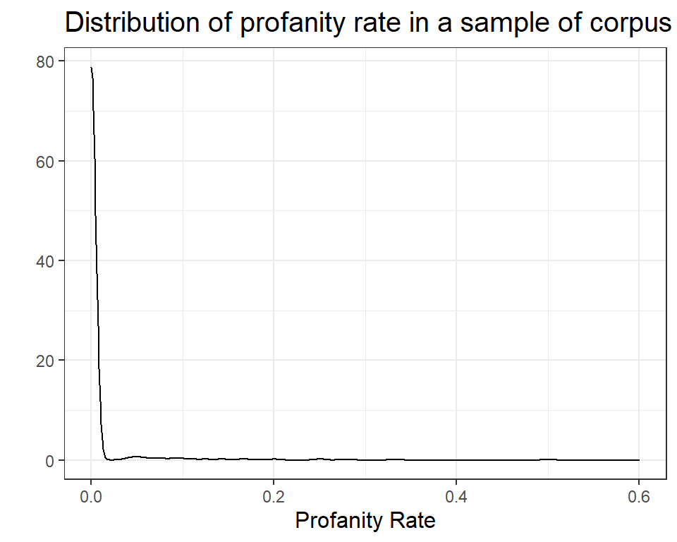

```r
set.seed(123)
s <- sample(1:100000, 10000)
profanity_list <- unique(lexicon::profanity_banned) #List containing stop words
twitter.profanity <- sentimentr::profanity(sapply(twitter_corpus[s], as.character),
                                    profanity_list=profanity_list)
twitter.profanity %>% ggplot(aes(x=profanity))+
            geom_density()+
            theme_bw()+
            labs(title="Distribution of profanity rate in a sample of corpus",
                 x = "Profanity Rate",
                 y="")+
            theme(axis.title = element_text(size = 12),
             plot.title = element_text(size = 15))
```

It seems that the profanity rate is very low through the twitter corpus. To filter this profanities, I used this list from the lexicon package and use the removeWords function from tm.

```r
twitter_corpus <- tm_map(twitter_corpus, removeWords, profanity_list)
twitter.profanity <- sentimentr::profanity(sapply(twitter_corpus[s], as.character),
                                    profanity_list=profanity_list)
mean(twitter.profanity$profanity)
```

```
## [1] 1.666667e-05
```

As we can see, the mean of the profanity rate is practically zero. The next step is to remove stop words from English language, it means, very common words that will affect the anaylis.

```r
twitter_corpus <- tm_map(twitter_corpus, removeWords, stopwords("english"))
```

Now, I remove some bad characters that appears because of the encoding of the .txt file. Finally, I strip the white spaces.

```r
subs <- function(x){
            x <- gsub("â", "", x)
            return(x)
}

twitter_corpus <- tm_map(twitter_corpus, content_transformer(subs))
my_stop_words <- c("â", "œ", "ðÿ")
twitter_corpus <- tm_map(twitter_corpus, removeWords, my_stop_words)
twitter_corpus <- tm_map(twitter_corpus, stripWhitespace)
```

Now, I create a table of the $1$-grams, that is, a table with the frequency of each word appearing on the Twitter corpus.

```r
twitter_1_grams <- tokenize_ngrams(sapply(twitter_corpus, as.character), n=1)
twitter_1_grams <- unlist(twitter_1_grams)
twitter_1_grams <- data.frame(table(twitter_1_grams))
twitter_1_grams <- twitter_1_grams %>% arrange(desc(Freq))
head(twitter_1_grams)
```

```
##   twitter_1_grams Freq
## 1              im 6757
## 2             get 6244
## 3            just 6221
## 4           thank 5555
## 5              go 5520
## 6            like 5475
```

Also, I create a table of the $2$ and $3$-grams of the corpus.

```r
twitter_2_grams <- tokenize_ngrams(sapply(twitter_corpus, as.character), n=2)
twitter_2_grams <- unlist(twitter_2_grams)
twitter_2_grams <- data.frame(table(twitter_2_grams))
twitter_2_grams <- twitter_2_grams %>% arrange(desc(Freq))
head(twitter_2_grams)
```

```
##   twitter_2_grams Freq
## 1       cant wait  744
## 2       right now  695
## 3      last night  543
## 4    thank follow  508
## 5    look forward  490
## 6       look like  464
```

```r
twitter_3_grams <- tokenize_ngrams(sapply(twitter_corpus, as.character), n=3)
twitter_3_grams <- unlist(twitter_3_grams)
twitter_3_grams <- data.frame(table(twitter_3_grams))
twitter_3_grams <- twitter_3_grams %>% arrange(desc(Freq))
head(twitter_3_grams)
```

```
##    twitter_3_grams Freq
## 1    cant wait see  152
## 2 happi mother day  149
## 3   happi new year   99
## 4      let us know   95
## 5 look forward see   53
## 6     feel like im   52
```

And finally, I create a document term matrix.

```r
twitter.dtm <- DocumentTermMatrix(twitter_corpus)
```

For the news and blogs files, the exact same process is done, with the same nomenclature. A random sample of 10000 news documents and 100000 blogs documents are taken, for the same reason as Twitter documents.

# EDA

Now, I start with the exploratory data analysis. My plan is:

- Create wordclouds of the most frequent words in each corpus
- Create plots of the most frequent words, $2$-grams and $3$-grams
- Compute the association of most frequent words
- Find distribution of most frequent words
- Find how many words are needed to cover the dictionaries

The following plot is a wordcloud of the most frequent words in Twitter corpus.

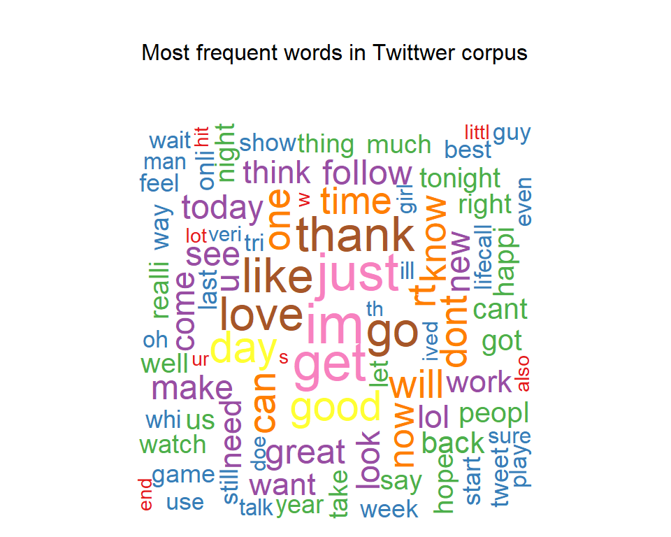

Now, I plot what are the fifteen most frequent words, $2$-grams and $3$-grams on Twitter Corpus

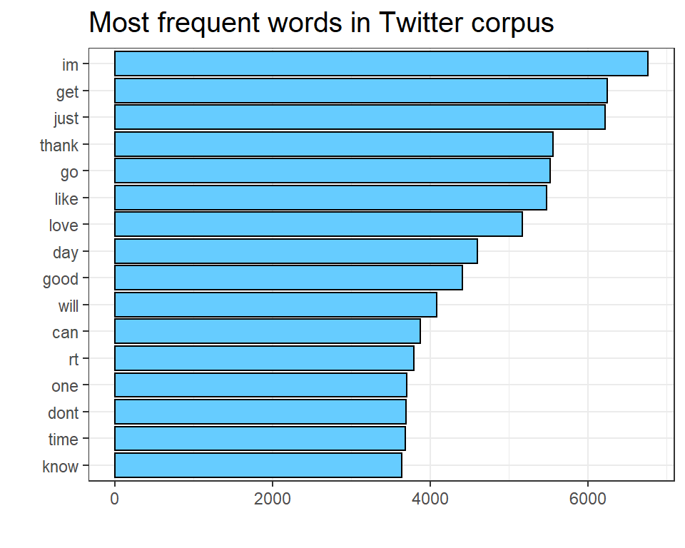

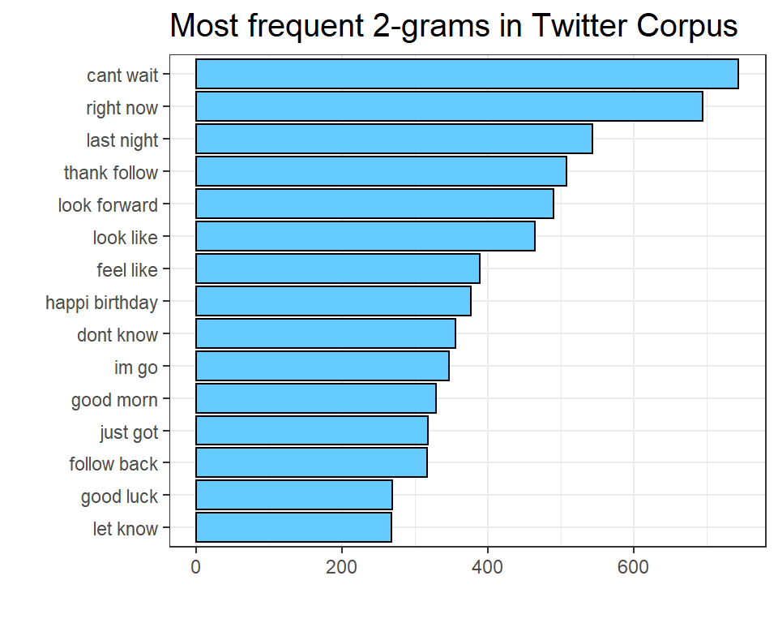

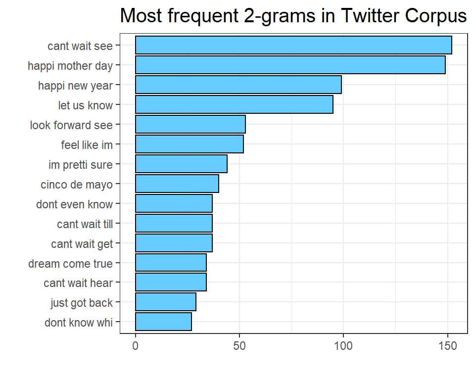

Now, the wordcloud and plots of the most frequent words, $2$-grams and $3$-grams in news.

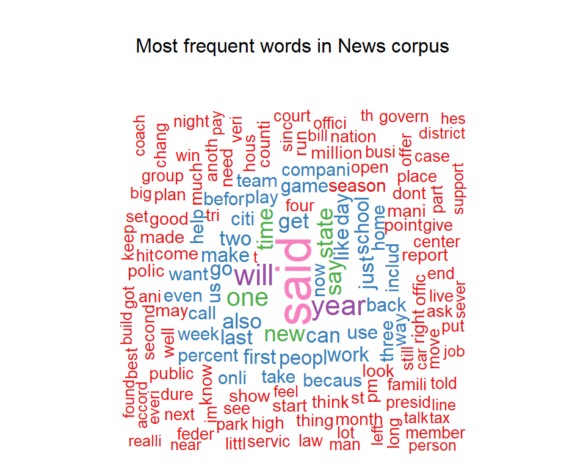

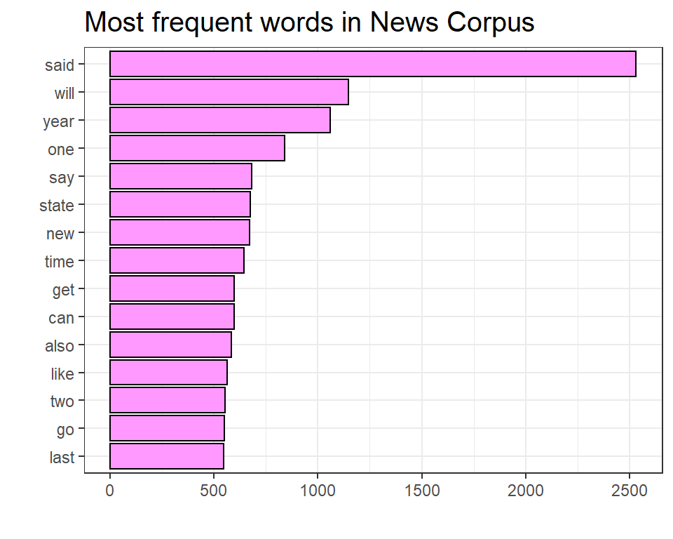

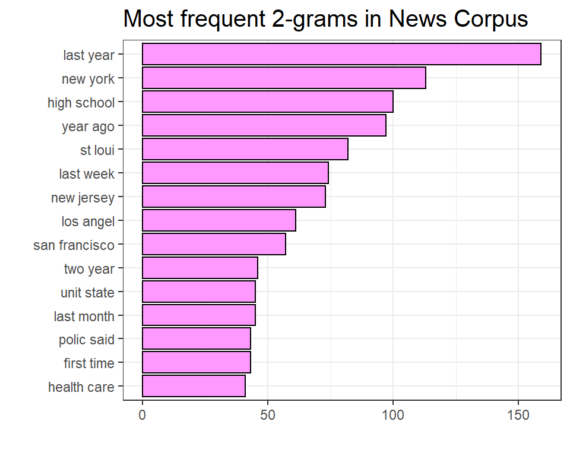

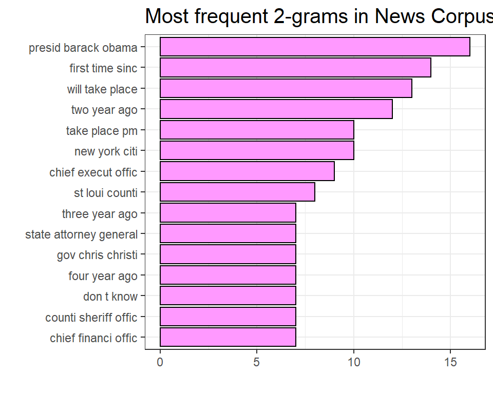

And the wordcloud and plots of the most frequent words, $2$-grams and $3$-grams in blogs.

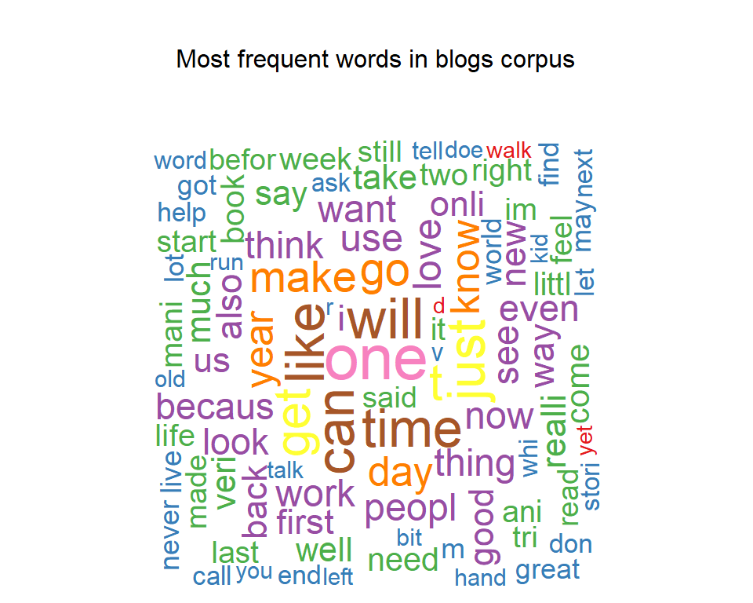

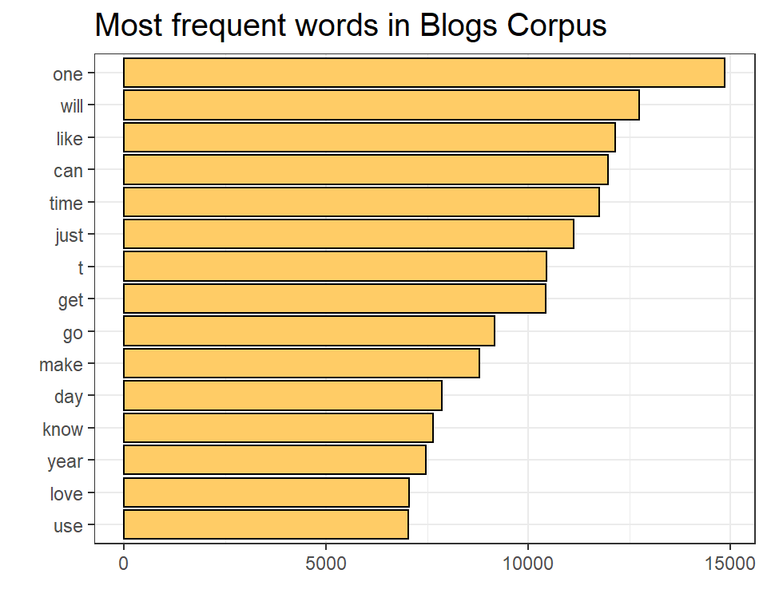

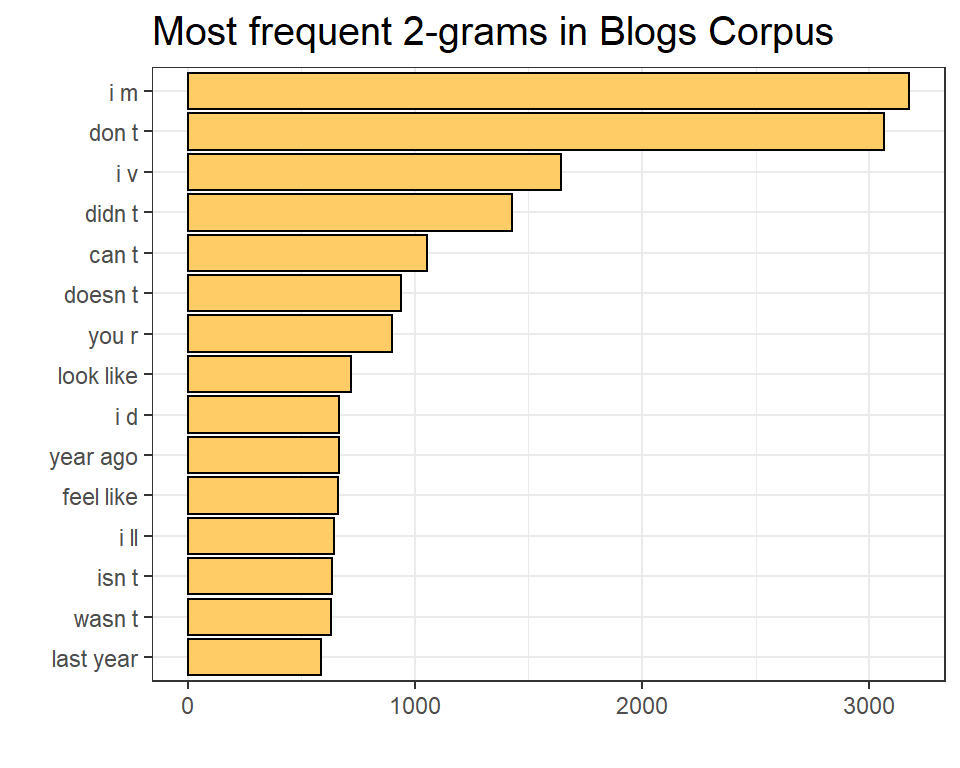

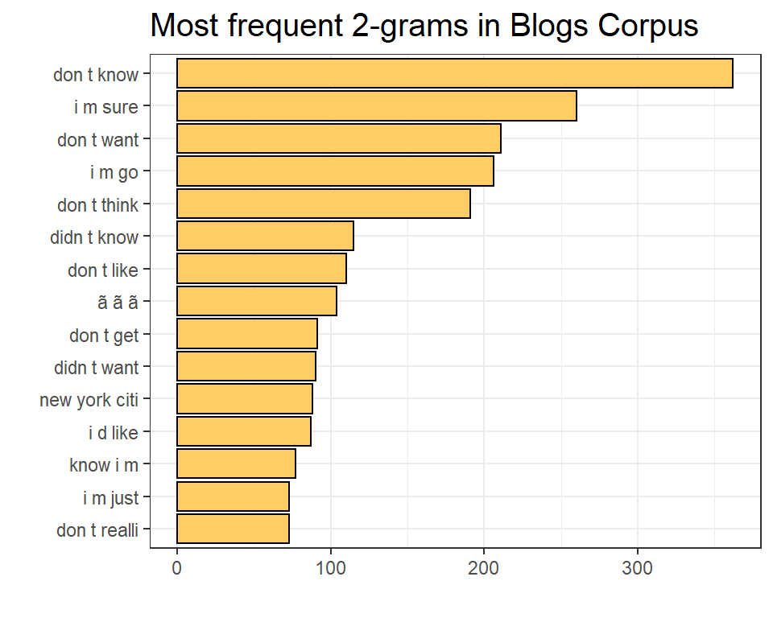

As expected, well elaborated sentences can be founded more frequently in the news and blogs corpora. Some aspects that should be considered is to remove certain “words”, such as “im”, “t” (which would be preceded by and apostrophe) and some other similar words and sentences.

Now, I find the association of the five most frequent words, with other words, that is, just the correlation in the document term matrix, with a minimun association fixed individually for each word.

```r
twitter_1_grams$word[1:5]
```

```
## [1] "im"    "get"   "just"  "thank" "go"
```

```r
findAssocs(twitter.dtm, "im", 0.005)
```

```
## $im
## numeric(0)
```

```r
findAssocs(twitter.dtm, "just", 0.05)
```

```
## $just
##    saw    got finish
##   0.09   0.08   0.07
```

```r
findAssocs(twitter.dtm, "get", 0.08)
```

```
## $get
## readi
##  0.12
```

```r
findAssocs(twitter.dtm, "thank", 0.08)
```

```
## $thank
## ooooohh  follow appreci support
##    0.13    0.12    0.09    0.08
```

```r
findAssocs(twitter.dtm, "go", 0.005)
```

```
## $go
## numeric(0)
```

It should be notice that, even with so low association bounds, there are no words associated to “im” and “go”, since this words are very common.

```r
news_1_grams$word[1:5]
```

```
## [1] "said" "will" "year" "one"  "say"
```

```r
findAssocs(news.dtm, "said", 0.08)
```

```
## $said
##   spokesman          \200\230 spokeswoman       peopl       think
##        0.10        0.09        0.09        0.08        0.08
```

```r
findAssocs(news.dtm, "will", 0.1)
```

```
## $will
##        vestig        sicker assemblywoman          duli      mosquera
##          0.19          0.14          0.12          0.12          0.12
##      tambussi       suffici adventureland       autopia      carsthem
##          0.12          0.12          0.12          0.12          0.12
##   fantasyland  frontierland          herd  piratescentr      rapunzel
##          0.12          0.12          0.12          0.12          0.12
##          take
##          0.10
```

```r
findAssocs(news.dtm, "year", 0.1)
```

```
## $year
##    last     ago million    next     cbo
##    0.26    0.26    0.13    0.11    0.11
```

```r
findAssocs(news.dtm, "one", 0.1)
```

```
## $one
##    alynn burrough  frerott   goodlo   marton sweetman     abbi      gin
##     0.22     0.22     0.22     0.22     0.22     0.22     0.19     0.16
##  neukomm mackenzi  tequila    maddi    clair     goal kirkwood
##     0.16     0.14     0.12     0.12     0.11     0.10     0.10
```

```r
findAssocs(news.dtm, "say", 0.1)
```

```
## $say
##    cimperman    rethought     abdullah       bespok  offtheshelf        paszk
##         0.11         0.11         0.11         0.11         0.11         0.11
## questionnair       stefan
##         0.11         0.11
```

```r
blogs_1_grams$word[1:5]
```

```
## [1] "one"  "will" "like" "can"  "time"
```

```r
findAssocs(blogs.dtm, "one", 0.1)
```

```
## $one
##   onli   just   like    two  anoth   time  thing    can  first    get   make
##   0.15   0.14   0.14   0.14   0.13   0.12   0.12   0.12   0.11   0.11   0.11
## becaus   even    day
##   0.10   0.10   0.10
```

```r
findAssocs(blogs.dtm, "will", 0.1)
```

```
## $will
## come  get make  can hope
## 0.11 0.11 0.11 0.11 0.11
```

```r
findAssocs(blogs.dtm, "like",0.1)
```

```
## $like
##   feel   just   look realli    one  thing becaus someth   know    get   make
##   0.18   0.17   0.17   0.14   0.14   0.14   0.13   0.13   0.12   0.12   0.12
##   felt   seem   time  think   even  peopl   much   dont    can don\200\231t   it\200\231
##   0.12   0.12   0.11   0.11   0.11   0.11   0.11   0.10   0.10   0.10   0.10
##  sound
##   0.10
```

```r
findAssocs(blogs.dtm, "can", 0.1)
```

```
## $can
##   see   get  make   one  just  help  will thing  onli peopl   way   use  know
##  0.14  0.13  0.13  0.12  0.11  0.11  0.11  0.11  0.11  0.11  0.11  0.11  0.10
##  even  like
##  0.10  0.10
```

```r
findAssocs(blogs.dtm, "time", 0.1)
```

```
## $time
##     just      get    spend    first      one     take      day     work
##     0.14     0.14     0.14     0.13     0.12     0.12     0.12     0.12
##   becaus     know    thing     like     much    everi     long    start
##     0.11     0.11     0.11     0.11     0.11     0.11     0.11     0.11
## cloudwel    edser  hypoton oramoprh     feel     mani    befor     even
##     0.11     0.11     0.11     0.11     0.10     0.10     0.10     0.10
```

As we can see, the most frequent words have very low associations with other words. This could explain why the most frequent $2$ and $3$-grams have relatively low frequencies.

Now, I find the central statistics for the ten most frequent words in each corpus.

```r
twitter.mfw <- DocumentTermMatrix(twitter_corpus,
                            list(dictionary=twitter_1_grams$word[1:10]))
twitter.mfw <- as.matrix(twitter.mfw)
twitter.mfw <- as.data.frame(twitter.mfw)
summary(twitter.mfw)
```

```
##       day               just              good             thank
##  Min.   :0.00000   Min.   :0.00000   Min.   :0.00000   Min.   : 0.00000
##  1st Qu.:0.00000   1st Qu.:0.00000   1st Qu.:0.00000   1st Qu.: 0.00000
##  Median :0.00000   Median :0.00000   Median :0.00000   Median : 0.00000
##  Mean   :0.04589   Mean   :0.06219   Mean   :0.04404   Mean   : 0.05551
##  3rd Qu.:0.00000   3rd Qu.:0.00000   3rd Qu.:0.00000   3rd Qu.: 0.00000
##  Max.   :4.00000   Max.   :3.00000   Max.   :5.00000   Max.   :10.00000
##       will              like              get               love
##  Min.   :0.00000   Min.   :0.00000   Min.   :0.00000   Min.   :0.00000
##  1st Qu.:0.00000   1st Qu.:0.00000   1st Qu.:0.00000   1st Qu.:0.00000
##  Median :0.00000   Median :0.00000   Median :0.00000   Median :0.00000
##  Mean   :0.04079   Mean   :0.05473   Mean   :0.06241   Mean   :0.05154
##  3rd Qu.:0.00000   3rd Qu.:0.00000   3rd Qu.:0.00000   3rd Qu.:0.00000
##  Max.   :4.00000   Max.   :4.00000   Max.   :4.00000   Max.   :7.00000
##        im          go
##  Min.   :0   Min.   :0
##  1st Qu.:0   1st Qu.:0
##  Median :0   Median :0
##  Mean   :0   Mean   :0
##  3rd Qu.:0   3rd Qu.:0
##  Max.   :0   Max.   :0
```

```r
news.mfw <- DocumentTermMatrix(news_corpus,
                               list(dictionary=news_1_grams$word[1:10]))
news.mfw <- as.matrix(news.mfw)
news.mfw <- as.data.frame(news.mfw)
summary(news.mfw)
```

```
##       can              get              year             said
##  Min.   :0.0000   Min.   :0.0000   Min.   :0.0000   Min.   :0.000
##  1st Qu.:0.0000   1st Qu.:0.0000   1st Qu.:0.0000   1st Qu.:0.000
##  Median :0.0000   Median :0.0000   Median :0.0000   Median :0.000
##  Mean   :0.0581   Mean   :0.0593   Mean   :0.1047   Mean   :0.253
##  3rd Qu.:0.0000   3rd Qu.:0.0000   3rd Qu.:0.0000   3rd Qu.:0.000
##  Max.   :5.0000   Max.   :3.0000   Max.   :5.0000   Max.   :4.000
##       will            state             say             one
##  Min.   :0.0000   Min.   :0.0000   Min.   :0.000   Min.   :0.0000
##  1st Qu.:0.0000   1st Qu.:0.0000   1st Qu.:0.000   1st Qu.:0.0000
##  Median :0.0000   Median :0.0000   Median :0.000   Median :0.0000
##  Mean   :0.1147   Mean   :0.0663   Mean   :0.068   Mean   :0.0838
##  3rd Qu.:0.0000   3rd Qu.:0.0000   3rd Qu.:0.000   3rd Qu.:0.0000
##  Max.   :8.0000   Max.   :6.0000   Max.   :3.000   Max.   :7.0000
##       time            new
##  Min.   :0.000   Min.   :0.000
##  1st Qu.:0.000   1st Qu.:0.000
##  Median :0.000   Median :0.000
##  Mean   :0.064   Mean   :0.067
##  3rd Qu.:0.000   3rd Qu.:0.000
##  Max.   :4.000   Max.   :4.000
```

```r
blogs.mfw <- DocumentTermMatrix(blogs_corpus,
                                list(dictionary=blogs_1_grams$word[1:10]))
blogs.mfw <- as.matrix(blogs.mfw)
blogs.mfw <- as.data.frame(blogs.mfw)
summary(blogs.mfw)
```

```
##       just             time              will              get
##  Min.   : 0.000   Min.   : 0.0000   Min.   : 0.0000   Min.   : 0.000
##  1st Qu.: 0.000   1st Qu.: 0.0000   1st Qu.: 0.0000   1st Qu.: 0.000
##  Median : 0.000   Median : 0.0000   Median : 0.0000   Median : 0.000
##  Mean   : 0.111   Mean   : 0.1167   Mean   : 0.1272   Mean   : 0.104
##  3rd Qu.: 0.000   3rd Qu.: 0.0000   3rd Qu.: 0.0000   3rd Qu.: 0.000
##  Max.   :12.000   Max.   :14.0000   Max.   :11.0000   Max.   :10.000
##       one              like             make              can
##  Min.   : 0.000   Min.   :0.0000   Min.   :0.00000   Min.   : 0.0000
##  1st Qu.: 0.000   1st Qu.:0.0000   1st Qu.:0.00000   1st Qu.: 0.0000
##  Median : 0.000   Median :0.0000   Median :0.00000   Median : 0.0000
##  Mean   : 0.147   Mean   :0.1211   Mean   :0.08771   Mean   : 0.1089
##  3rd Qu.: 0.000   3rd Qu.:0.0000   3rd Qu.:0.00000   3rd Qu.: 0.0000
##  Max.   :10.000   Max.   :8.0000   Max.   :8.00000   Max.   :11.0000
##        t           go
##  Min.   :0   Min.   :0
##  1st Qu.:0   1st Qu.:0
##  Median :0   Median :0
##  Mean   :0   Mean   :0
##  3rd Qu.:0   3rd Qu.:0
##  Max.   :0   Max.   :0
```

As we can see, frequencies are relatively low in each corpus.

Finally, I check how many words are needed to cover the dictionaries.

```r
(twitter.q <- quantile(twitter_1_grams$freq, probs = c(0.5,0.9,0.95)))
```

```
## 50% 90% 95%
##   1  12  37
```

```r
(news.q <- quantile(news_1_grams$freq, probs = c(0.5,0.9,0.95)))
```

```
## 50% 90% 95%
##   1  16  38
```

```r
(blogs.q <- quantile(blogs_1_grams$freq, probs = c(0.5,0.9,0.95)))
```

```
## 50% 90% 95%
##   1  18  56
```

```r
for(i in 1:3){
    w <- sum(twitter_1_grams$freq<=twitter.q[i])
    p <- paste(names(twitter.q)[i],"of the twitter dictionary")
    p <- paste(p, "is covered by ", as.character(w), "words." )
    print(p)
}
```

```
## [1] "50% of the twitter dictionary is covered by  31680 words."
## [1] "90% of the twitter dictionary is covered by  45120 words."
## [1] "95% of the twitter dictionary is covered by  47639 words."
```

```r
print(paste("There are", as.character(dim(twitter_1_grams)[1]),
            "unique words in twitter corpus."))
```

```
## [1] "There are 50112 unique words in twitter corpus."
```

```r
for(i in 1:3){
    w <- sum(news_1_grams$freq<=news.q[i])
    p <- paste(names(news.q[i]), "of the news dictionary")
    p <- paste(p, "is covered by", as.character(w), "words.")
    print(p)
}
```

```
## [1] "50% of the news dictionary is covered by 11436 words."
## [1] "90% of the news dictionary is covered by 19948 words."
## [1] "95% of the news dictionary is covered by 20992 words."
```

```r
print(paste("There are", as.character(dim(news_1_grams)[1]),
      "unique words in news corpus."))
```

```
## [1] "There are 22086 unique words in news corpus."
```

```r
for(i in 1:3){
    w <- sum(blogs_1_grams$freq<=news.q[i])
    p <- paste(names(blogs.q[i]), "of the blogs dictionary")
    p <- paste(p, "is covered by", as.character(w), "words.")
    print(p)
}
```

```
## [1] "50% of the blogs dictionary is covered by 49034 words."
## [1] "90% of the blogs dictionary is covered by 77729 words."
## [1] "95% of the blogs dictionary is covered by 81339 words."
```

```r
print(paste("There are", as.character(dim(blogs_1_grams)[1]),
      "unique words in news corpus."))
```

```
## [1] "There are 86734 unique words in news corpus."
```

# Conclusions.

It seems that, in order to fine well elaborated sentences that could be useful to train a text prediction model, it is better to consider news and blogs. But It should be noticed that it is more likely to find “natural language” on twitter corpus, that means, the way people usually use to communicate in a casual way may be found on twitter, although may be complicated to train a model with this data.

# Model

For the text prediction model, I plan to use sbo library, which contains functions to pre-process, train, predict and evaluate text and it is based on back-off models. My goal is to train the model using different parameters and pre-proccesings to train a highly accurate text prediction models.

Some of the challenges with this approach have to do with time and memory efficiency, although sbo package has some functions that seem to cope with these challenges. Another challenge has to do with splitting the data to evaluate the model.